# The Effect of India’s 1996 Lok Sabha Election on Pollution Abatement and Monitoring

Michael Jerman

October 28, 2020

# Introduction

- Puzzle: India has high levels of water pollution and high abatement expenditures
- Potential causes:
  - High marginal abatement costs
  - Marginal effects of abatement on pollution are low
  - Weak institutions/poor oversight
  - Corruption
  - Information shortages
  - Inefficient allocation of abatement infrastructure
- This paper: Clientelism as a source of inefficient allocation of environmental resources

# Summary

- Electorally competitive cities are more likely to receive abatement funding from the federal government
- Competitive cities are *less* likely to have water pollution monitoring
- Social cost of inefficiencies are unknowable due to poor pollution monitoring

# Background

- Politics in India:
  - First-past-the-post voting
  - Castes vote monolithically (more or less)
  - Local communities benefit from same-caste leaders (state and local)
  - Many opportunities for clientelism (vote trading)

# Background, Continued

- Lok Sabha (parliament) election of 1996:
  - Highly contested, hung parliament
  - Electoral turmoil: 5 governments and 3 elections in next 5 years
  - Two main coalitions (Congress, BJP) fighting for power
  - Districts change hands frequently following 1996 election

Electoral Margin of Victory, 1996 Lok Sabha Elections

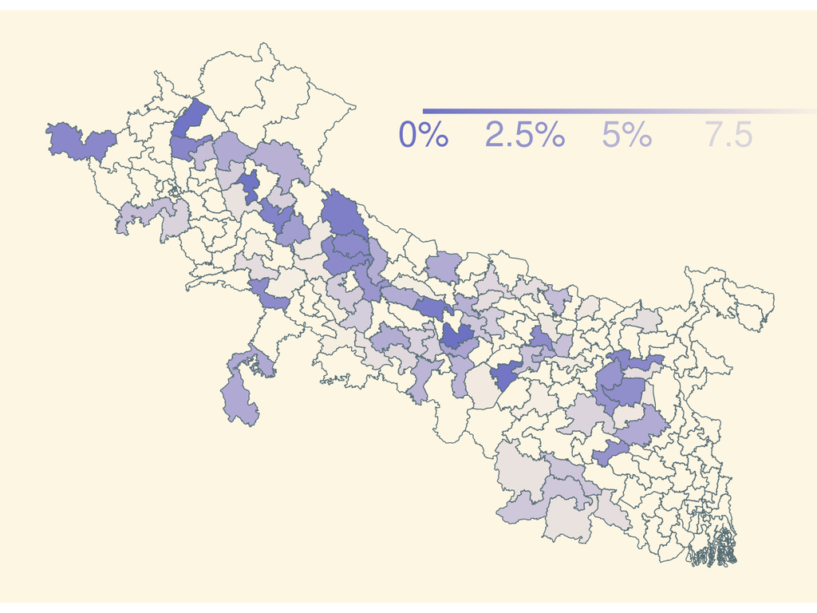

# Background, Continued

- Ganga Action Plan, Phase II (GAP II)
  - Administered by the federal government from 1996
  - $9 billion USD allocated to abatement projects along Ganges and tributaries
  - Allocation process is opaque, little oversight

Major Cities Receiving and Not Receiving GAP-II Funding

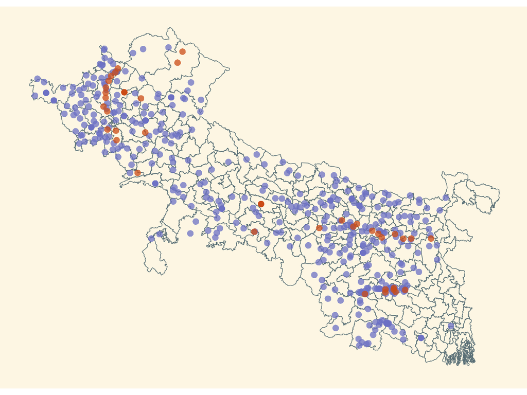

# Identification

- Main hypothesis: Policymakers disproportionately allocate environmental resources to competitive districts
- Treatment variable: Electoral margin of victory less than 3%
  - Districts contested by main coalitions only
- Binary outcome variables:
  - GAP II allocations to cities
  - Water quality monitoring downstream of a city after 1996
- Identification assumption: Abatement requirements in electorally competitive districts are similar to non-competitive districts (conditional on observables)

# Econometric Specification

$$Y_i = \beta D^\text{Close Election}_i + X_i \gamma + \varepsilon_i$$

- Observations are cities $i$ in the Ganges basin
- $Y_i$: Binary outcome variable (GAP II funding or water quality monitoring)
- Control variables $X_i$:
  - Population
  - Distance from Ganges or tributary (quadratic)
  - Nighttime light activity (level and trend)
  - Prior inclusion into federal abatement program (GAP I)
  - State and party fixed effects
- Estimated with probit link function

### Estimated Average Marginal Effect of Close Elections on Probability of Receiving GAP-II Funding: Margin of Victory **< 3%**, **< 5%**, and **< 7%**

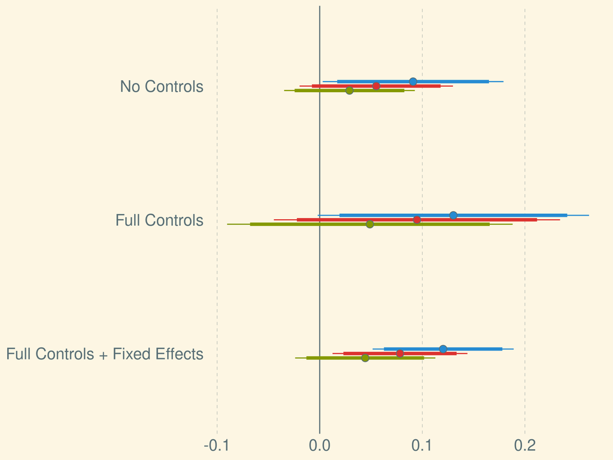

# GAP II Results

- Electorally competitive cities more likely to receive GAP II funding
- Robustness checks:
  - Competition in 1996 does not predict prior allocations
  - Effect decreases as treatment variable becomes more inclusive
  - No effect in non-competitive cities with similar electoral compositions
  - Results robust to alternative link functions
  - Results not driven by winning-party effects

# Water Quality Monitoring Stations (WQMS)

- Sparse network of water quality monitoring stations administered by Central Pollution Control Board and Central Water Commission
- Most cities do not have downstream monitoring stations
- Dependent variable: WQMS opens downstream of city within three years of election
- Downstream distance: 10km, 20km

Estimated Average Marginal Effect of Close Elections on Probability of Downstream WQMS Introduction:  
Downstream Distance **< 10km** and **< 20km**

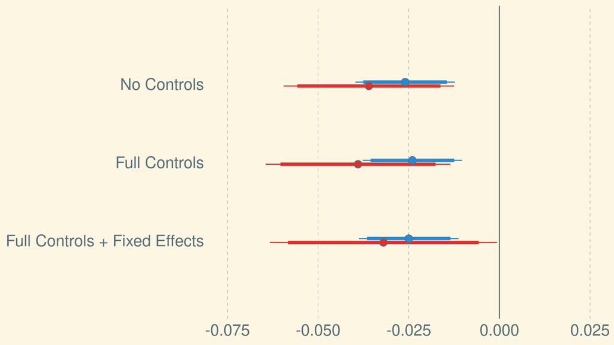

# WQMS Results

- Electorally competitive cities less likely to have pollution monitoring
- Explanation:
  - Pollution levels are high, abatement expenditures are ineffective
  - Pollution monitoring highlights institutional failures -Robustness:
  - Electoral competition does not predict prior WQMS locations
  - Results robust to alternative link functions

# Conclusion

- Main results: Electorally competitive cities are
  - more likely to receive GAP II funding
  - less likely to have pollution monitoring
- Social costs
  - Impossible to calculate
  - Pollution levels and abatement effects unobserved
  - Where abatement expenditures should be allocated is impossible to calculate
- Policy implication: Drastic expansion of WQMS network
- Research frontier: Remote sensing of water pollution levels